# Homework 3

Kirk Vanacore

9/23/2021

## Load/Setup STRAN

```r
library(rstan) # observe startup messages
options(mc.cores = parallel::detectCores()) # Use all local cores (does this work for all r packages?)
rstan_options(auto_write = TRUE) # saves stan to hard drive
Sys.setenv(TZ = "America/Toronto") # this deals with a time zone bug issue that was causes an error when running the model
library(dplyr)
```

# Homework 3

1. make a stan_data object like this: > stan_data= list(N=nrow(dat), y=dat$post.math.total,pretest=dat$pre.math.total)

(modify as necessary–the point is that you are creating a list of all of the data elements that you put in the data{} part of the stan model)

2. fit the model like this (again, modify as necessary) > fit=stan(“regression1.stan”, data=stan_data)
3. check out the results

extra credit: put in another predictor

###Save in file .stan

```
// The input data is a vector 'y' of length 'N'.
data {
  int<lower=0> N;
  vector[N] y;
  vector[N] pretest_MC;
}

// yi = b0 + b1xi1 + ei
// ei ~ N(0, sigma)
// yi ~ N(b0 + b1xi1, sigma) <- This is the modle


// The parameters accepted by the model. Our model
// accepts two parameters 'mu' and 'sigma'.
parameters {
  real<lower=0> sigma;
  real b0;
  real b1;
}

// The model to be estimated. We model the output
// 'y' to be normally distributed with mean 'mu'
// and standard deviation 'sigma'.
model {
  y ~ normal(b0 + b1*pretest_MC, sigma);
}
```

## Prepare data

```r
assess <-read.csv("Assessment_merged_2021_07_16_state_assessment_N=4321 - Sheet1.csv", na.strings = c(""))
colnames(assess)
```

```
##   [1] "student_number"                   "student_id"
##   [3] "rdm_condition"                    "condition_assignment"
##   [5] "FH2T"                             "DragonBox"
##   [7] "Instant"                          "Delay"
##   [9] "initial_school_id"                "virtual"
##  [11] "initial_teacher_id"               "initial_teacher_class"
##  [13] "initial_section_number"           "final_school_id"
##  [15] "final_teacher_id"                 "final_teacher_class"
##  [17] "final_section_number"             "courseName"
##  [19] "movement"                         "stay_INPERSON"
##  [21] "stay_VIRTUAL"                     "INP_VIR"
##  [23] "VIR_INP"                          "KEEP"
##  [25] "student_raceEthnicityFed"         "student_hispanicEthnicity"
##  [27] "FEMALE"                           "MALE"
##  [29] "ScaleScore_5th.grade"             "PerformanceLevel_5th.grade"
```

[output cut: 76 more lines]

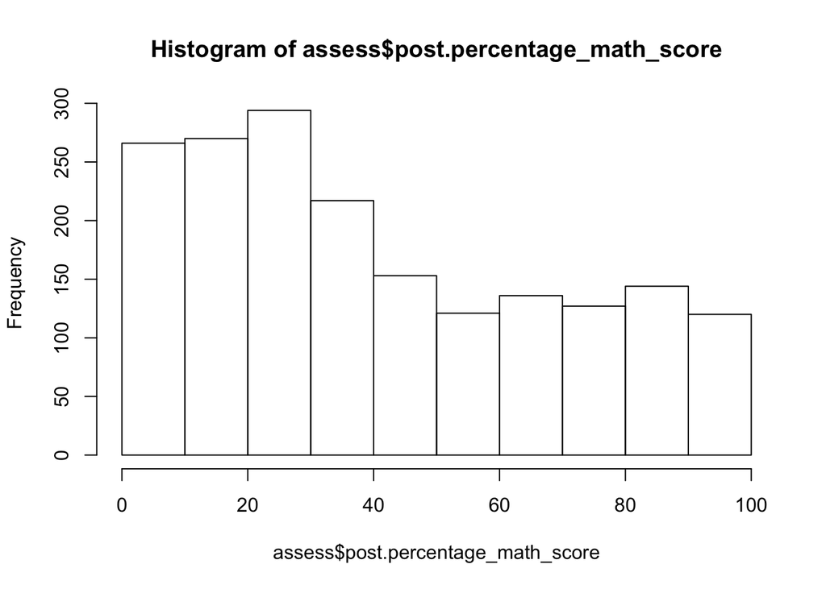

```r
# Clean data
assess <- assess %>%
  filter(is.na(post.percentage_math_score) == F,
         is.na(pre.percentage_math_score) == F,

    # remove students who are not in original random assignment
    is.na(rdm_condition) == F,
    # remove students who are in resource
     assess$rdm_condition != "Dragon-Resource" & assess$rdm_condition != "FH2T-Resource",
    # S03 drop schools
     final_school_id != "S03" & initial_school_id != "S03"
    & final_school_id != "S07" & initial_school_id != "S07"

  )


#
hist(assess$post.percentage_math_score)
```

```r
assess$pre.percentage_math_score_MC <- assess$pre.percentage_math_score- mean(assess$pre.percentage_math_score)


stan_data1 <-  list(N=nrow(assess),
                   y=assess$post.percentage_math_score,
                   pretest_MC=assess$pre.percentage_math_score_MC)
```

And we can get a fit with the following R command. Note that the argument to file = should point to where the file is on your file system unless you have put it in the working directory of R in which case the below will work.

# Model1: Predicting post test from prestest

```r
fit1 <- stan(file = 'HW3stanScript.stan',
            data = stan_data1)
```

## Output

```r
print(fit1)
```

```
## Inference for Stan model: HW3stanScript.
## 4 chains, each with iter=2000; warmup=1000; thin=1;
## post-warmup draws per chain=1000, total post-warmup draws=4000.
##
##           mean se_mean   sd     2.5%      25%      50%      75%    97.5% n_eff
## sigma    22.39    0.01 0.37    21.68    22.15    22.38    22.64    23.12  5134
## b0       45.62    0.01 0.51    44.59    45.28    45.62    45.97    46.64  3285
## b1        0.69    0.00 0.02     0.65     0.68     0.69     0.70     0.73  4283
## lp__  -6665.42    0.03 1.26 -6668.77 -6665.99 -6665.10 -6664.49 -6664.02  2095
##       Rhat
## sigma    1
## b0       1
## b1       1
## lp__     1
##
## Samples were drawn using NUTS(diag_e) at Thu Sep 30 11:13:25 2021.
## For each parameter, n_eff is a crude measure of effective sample size,
## and Rhat is the potential scale reduction factor on split chains (at
## convergence, Rhat=1).
```

# Model 2

## Stan Code

```
//
// This Stan program defines a simple model, with a
// vector of values 'y' modeled as normally distributed
// with mean 'mu' and standard deviation 'sigma'.
//
// Learn more about model development with Stan at:
//
//    http://mc-stan.org/users/interfaces/rstan.html
//    https://github.com/stan-dev/rstan/wiki/RStan-Getting-Started
//

// The input data is a vector 'y' of length 'N'.
data {
  int<lower=0> N;
  vector[N] y;
  vector[N] pretest_MC;
  vector[N] FH2T;
  vector[N] Dragon;
  vector[N] ASSISTments;


}

// The parameters accepted by the model. Our model
// accepts two parameters 'mu' and 'sigma'.
parameters {
  real<lower=0> sigma;
  real b0;
  real b1;
  real b2;
  real b3;
  real b4;
}

// The model to be estimated. We model the output
model {
  y ~ normal(b0
    + b1*pretest_MC
    + b2*FH2T
    + b3*Dragon
    + b4*ASSISTments , sigma);
}

generated quantities {
  vector[N] yhat;
//vector[N] ynew;
  for(i in 1:N){
    yhat[i] = b0
    + b1*pretest_MC
    + b2*FH2T
    + b3*Dragon
    + b4*ASSISTments

  }

}
```

## Prepare Data

```r
# Dummy Code
table(assess$rdm_condition)
```

```
##
##     ASSISTments             BAU          Dragon Dragon-Resource            FH2T
##             380             366             349               0             753
##   FH2T-Resource
##               0
```

```r
assess$FH2T <- ifelse(assess$rdm_condition == "FH2T", 1, 0)
table(assess$rdm_condition, assess$FH2T)
```

```
##
##                     0   1
##   ASSISTments     380   0
##   BAU             366   0
##   Dragon          349   0
##   Dragon-Resource   0   0
##   FH2T              0 753
##   FH2T-Resource     0   0
```

```r
assess$ASSISTments <- ifelse(assess$rdm_condition == "ASSISTments", 1, 0)
table(assess$rdm_condition, assess$ASSISTments)
```

```
##
##                     0   1
##   ASSISTments       0 380
##   BAU             366   0
##   Dragon          349   0
##   Dragon-Resource   0   0
##   FH2T            753   0
##   FH2T-Resource     0   0
```

```r
assess$Dragon <- ifelse(assess$rdm_condition == "Dragon", 1, 0)
table(assess$rdm_condition, assess$Dragon)
```

```
##
##                     0   1
##   ASSISTments     380   0
##   BAU             366   0
##   Dragon            0 349
##   Dragon-Resource   0   0
##   FH2T            753   0
##   FH2T-Resource     0   0
```

```r
nrow(assess)
```

```
## [1] 1848
```

```r
stan_data2 <-  list(N=nrow(assess),
                   y=assess$post.percentage_math_score,
                   pretest_MC=assess$pre.percentage_math_score_MC,
                   FH2T = assess$FH2T,
                   ASSISTments = assess$ASSISTments,
                   Dragon = assess$Dragon)
```

# Model2: Estimaiting treatment effects

```r
fit2 <- stan(file = 'HW3stanScript2.stan',
            data = stan_data2)
```

```r
print(fit2)
```

[output not shown]

[output cut: 3666 more lines]

[output not shown]

How do I evaluate the Coefficients For example: b2 CIs (maybe that is not what they are) overlap zero. Does this mean that we can’t say that it is 95% probable that the effect of FH2T is not zero? I’m I think about this incorrectly because are not doing null hypotheses testing.

```
## 'pars' not specified. Showing first 10 parameters by default.
```

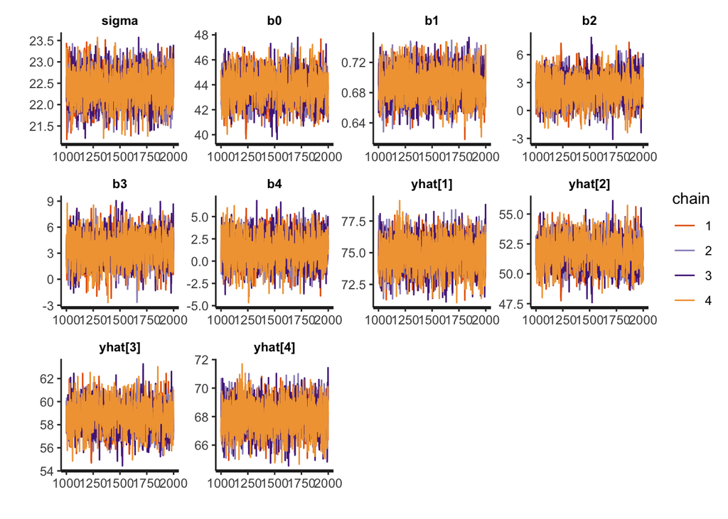

```r
traceplot(fit2,inc_warmup =F)
```

```r
print(fit2,par="yhat",include=FALSE)
```

```
## Inference for Stan model: HW3stanScript2.
## 4 chains, each with iter=2000; warmup=1000; thin=1;
## post-warmup draws per chain=1000, total post-warmup draws=4000.
##
##           mean se_mean   sd     2.5%      25%      50%      75%    97.5% n_eff
## sigma    22.39    0.01 0.37    21.66    22.14    22.38    22.64    23.13  3206
## b0       43.75    0.03 1.16    41.46    42.97    43.75    44.54    46.02  1344
## b1        0.69    0.00 0.02     0.65     0.68     0.69     0.70     0.73  2815
## b2        2.31    0.04 1.43    -0.46     1.35     2.34     3.26     5.05  1628
## b3        3.49    0.04 1.68     0.23     2.39     3.48     4.62     6.78  1642
## b4        1.30    0.04 1.64    -1.89     0.22     1.28     2.41     4.48  1712
## lp__  -6664.55    0.04 1.73 -6668.78 -6665.50 -6664.19 -6663.27 -6662.15  1902
##       Rhat
## sigma    1
## b0       1
## b1       1
## b2       1
## b3       1
## b4       1
## lp__     1
##
## Samples were drawn using NUTS(diag_e) at Thu Sep 30 11:14:03 2021.
## For each parameter, n_eff is a crude measure of effective sample size,
## and Rhat is the potential scale reduction factor on split chains (at
## convergence, Rhat=1).
```

```r
# n_eff -> higher -> less correlation between successive draws for post dist
  # higher is better -> more confident
  # effective DF -> the draws that you have are giving you and equal amounts of information that many indepoendet draws
  # did the chain fit the data well (not the same as does the model produced by the chain fit the data well)
```

```r
# gives you the draws
samp <- extract(fit2, pars="yhat",include=FALSE)
head(samp$b1)
```

```
## [1] 0.6871349 0.6807926 0.6840117 0.6923336 0.7430121 0.6985950
```

```r
mean(samp$b1)
```

```
## [1] 0.6907594
```

```r
mean(samp$b1>0)
```

```
## [1] 1
```

```r
mean(samp$b2>samp$b3) # probability that one condition will produce
```

```
## [1] 0.2065
```

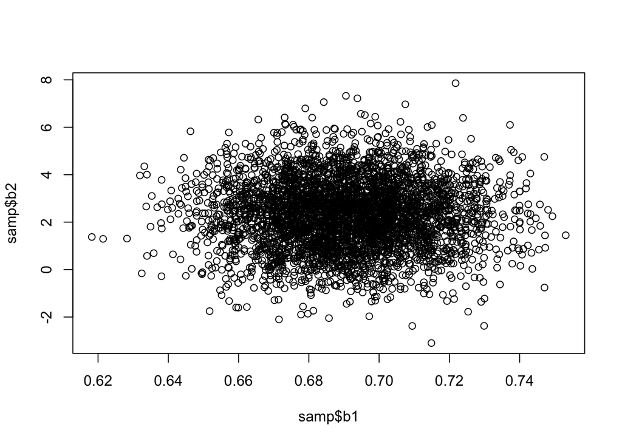

```r
plot(samp$b1, samp$b2)
```